# Test

## 1.

Nacteni dat

```r
library(readxl)
data <- read_xlsx('p5.xlsx')
# View(data)
opo <- data$opotrebenie
```

Tabulky

```r
# absolutni poc, oba slopce
apply(data, 2, table)
```

```
$miesto

 1  2  3
17 13 20

$opotrebenie

48 49 58 60 61 62 63 64 67 68 69 70 71 72 73 74 75 76 77 78 79 80 81 82 83 84
 2  1  1  2  1  2  1  2  2  2  1  1  2  1  1  1  6  1  1  1  2  3  2  1  1  2
86 88 89 90 95 97
 1  1  1  2  1  1
```

```r
# relativni poc, jen opotrebeni
table(data$opotrebenie) / length(data$opotrebenie)
```

```
  48   49   58   60   61   62   63   64   67   68   69   70   71   72   73   74
0.04 0.02 0.02 0.04 0.02 0.04 0.02 0.04 0.04 0.04 0.02 0.02 0.04 0.02 0.02 0.02
  75   76   77   78   79   80   81   82   83   84   86   88   89   90   95   97
0.12 0.02 0.02 0.02 0.04 0.06 0.04 0.02 0.02 0.04 0.02 0.02 0.02 0.04 0.02 0.02
```

Charakteristiky

Mean, median i modest maji podobnou hodnotu. Smerodatna odchylka je mensi vzhledem k max-min hodnote. Data nejsou “divoka”. Data nejsou úplne symetrická, ale vychýlená do doprava (zaporna skewness). Zároveň jsou o něco více zploštělá (skewness). Teoreticky by se mohlo jedna o normalini distribuci.

```r
min(opo); max(opo)
```

```
[1] 48
```

```
[1] 97
```

```r
mean(opo)
```

```
[1] 73.56
```

```r
median(opo)
```

```
[1] 75
```

```r
library(modeest)
mfv(opo)
```

```
[1] 75
```

```r
var(opo)
```

```
[1] 128.782
```

```r
sqrt(var(opo))
```

```
[1] 11.34822
```

```r
library(e1071)
skewness(opo) # sikmost
```

```
[1] -0.2734841
```

```r
kurtosis(opo) # spocatost
```

```
[1] -0.2580989
```

Ploty

Histogram vypada na normalni rozdeleni.

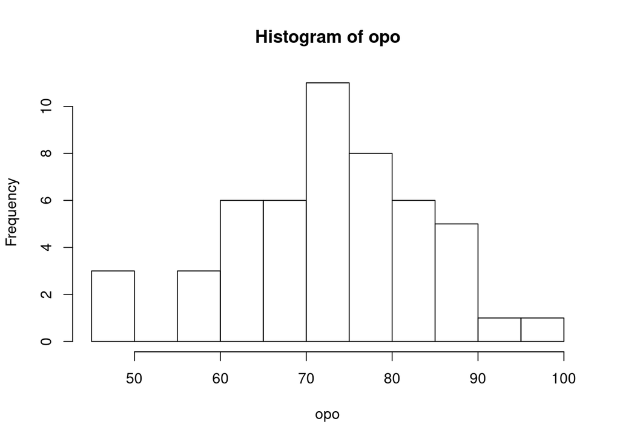

```r
library(ggplot2)
library(vioplot)
# library(MASS)
# library(RColorBrewer)

hist(opo)
```

Stehne tak i box plot vypada normalne. Hodnoty jsou lehce posunute doprava (shoduje se se skewness). Nejsou tu zadne vybocujici hodnoty.

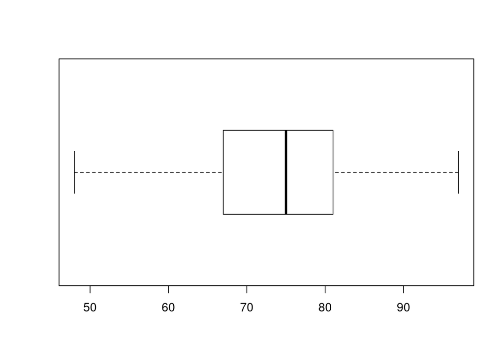

```r
boxplot(opo, horizontal=T)
```

Pri vykresleni po miste mereni maji vsechny tri kategorie podobny tavr boxplotu, ale je mezi nimi videt rozdil. 2 a 3 vypadaji nejvice odlisne, maji jinde median, u 2 se hodnoty drzi vice stredu, u 3 jsou vice roztahle do sirky.

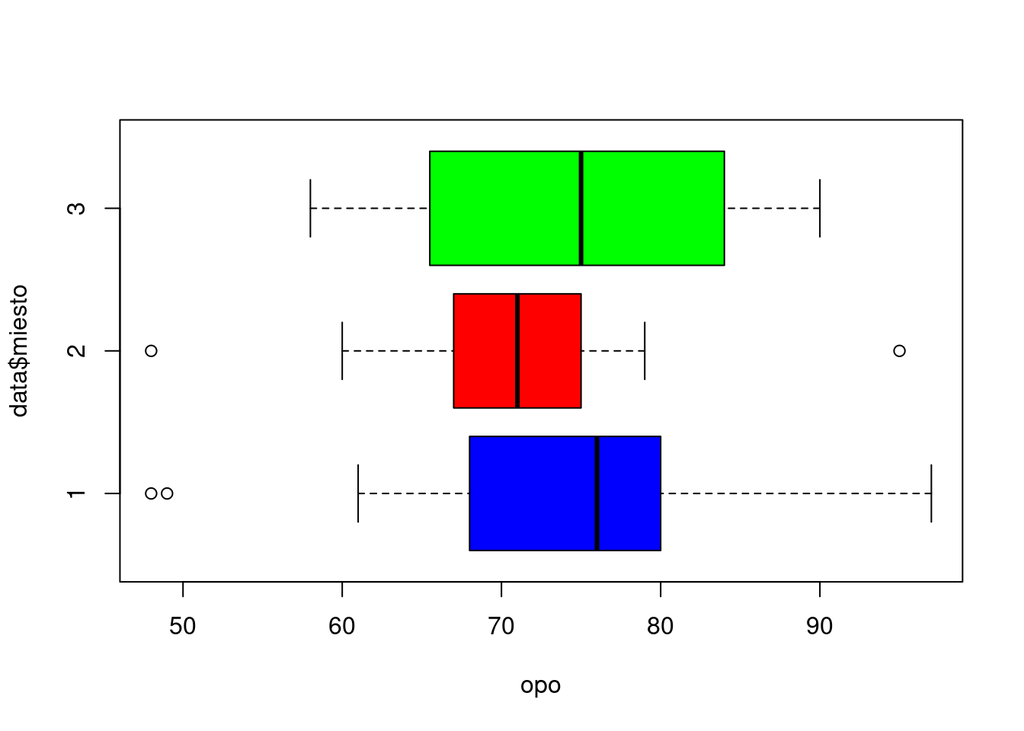

```r
boxplot(opo~data$miesto, col=c('blue', 'red', 'green'), horizontal=T)
```

U violinplotu se vizualne nejvice odlisuje 3.

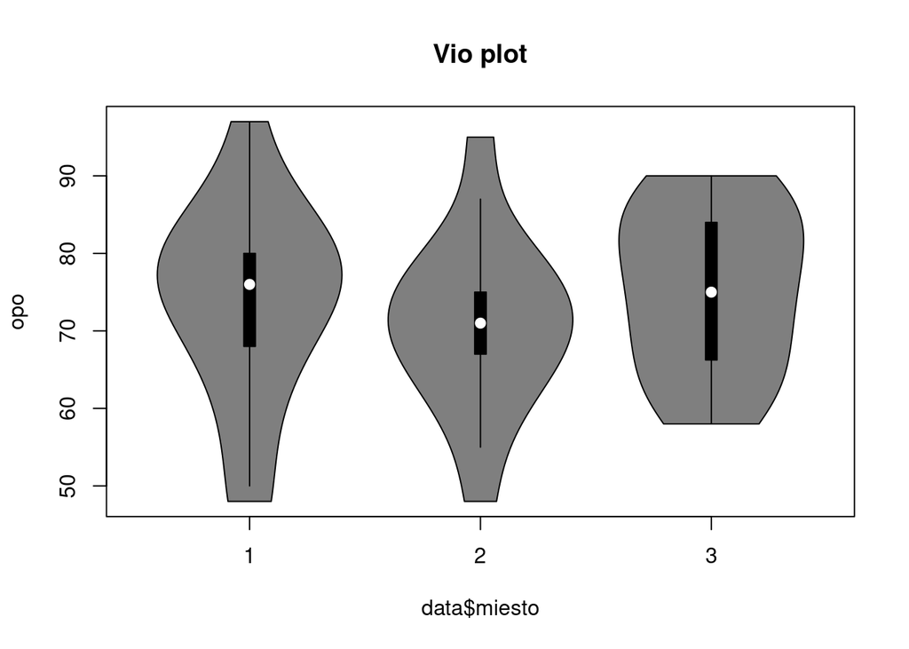

```r
vioplot::vioplot(opo~data$miesto, main='Vio plot')
```

## 2.

Test na normalitu

Data jsou normalne rozdelena, p-hodnota je > 0.05.

```r
shapiro.test(opo)
```

```
    Shapiro-Wilk normality test

data:  opo
W = 0.98109, p-value = 0.5989
```

Intervalovy odhad - stredni hodnota

```r
t.test(opo, conf.level = 0.90)$conf.int
```

```
[1] 70.86934 76.25066
attr(,"conf.level")
[1] 0.9
```

```r
t.test(opo, conf.level = 0.90, alternative="less")$conf.int  # pravostranny <-inf, k>
```

```
[1]     -Inf 75.64485
attr(,"conf.level")
[1] 0.9
```

Intervalovy odhad - disperze

```r
library(EnvStats)
varTest(opo, alternative = "two.sided", conf.level = 0.90)$conf.int
```

```
      LCL       UCL
 95.12283 185.97887
attr(,"conf.level")
[1] 0.9
```

```r
varTest(opo, alternative = "less", conf.level = 0.90)$conf.int
```

```
     LCL      UCL
  0.0000 171.3912
attr(,"conf.level")
[1] 0.9
```

## 3.

Porovnani 2 verzi

```r
mu <- 80
sd <- 10
```

Test na normalitu. P-hodnota je > 0.05, jedna se o normalni rozdeleni.

```r
shapiro.test(opo)
```

```
    Shapiro-Wilk normality test

data:  opo
W = 0.98109, p-value = 0.5989
```

```r
# odchylka na tyto data sedi, pouzijeme ji
varTest(opo, sigma.squared = 10*10)
```

```
Results of Hypothesis Test
--------------------------

Null Hypothesis:                 variance = 100

Alternative Hypothesis:          True variance is not equal to 100

Test Name:                       Chi-Squared Test on Variance

Estimated Parameter(s):          variance = 128.782

Data:                            opo

Test Statistic:                  Chi-Squared = 63.1032

Test Statistic Parameter:        df = 49

P-value:                         0.1697341

95% Confidence Interval:         LCL =  89.86191
                                 UCL = 199.97898
```

```r
# test, kdy sd nezname
# t.test(opo, mu = mu, alternative = 'less')$p.value
library(DescTools)
ZTest(opo,mu=mu,sd_pop=10, alternative = 'greater')
```

```
    One Sample z-test

data:  opo
z = -4.5538, Std. Dev. Population = 10, p-value = 1
alternative hypothesis: true mean is greater than 80
95 percent confidence interval:
 71.23383      Inf
sample estimates:
mean of x
    73.56
```

## 4.

Nahodnost mereni. Podle obou testu byla mereni opravdu nahodna.

```r
library(randtests)
runs.test(opo, plot = F) # spojity
```

```
    Runs Test

data:  opo
statistic = 1.5425, runs = 28, n1 = 21, n2 = 23, n = 44, p-value =
0.1229
alternative hypothesis: nonrandomness
```

```r
turning.point.test(opo) # periodicita
```

```
    Turning Point Test

data:  opo
statistic = 0.23786, n = 46, p-value = 0.812
alternative hypothesis: non randomness
```

Neparametricky test.

I neparametricky test ma stejne vysledky.

```r
library(BSDA)
SIGN.test(opo, md = mu, alternative = 'greater')
```

```
    One-sample Sign-Test

data:  opo
s = 13, p-value = 0.9995
alternative hypothesis: true median is greater than 80
95 percent confidence interval:
  71 Inf
sample estimates:
median of x
         75

Achieved and Interpolated Confidence Intervals:

                  Conf.Level L.E.pt U.E.pt
Lower Achieved CI     0.9405     71    Inf
Interpolated CI       0.9500     71    Inf
Upper Achieved CI     0.9675     71    Inf
```

## 5.

ANOVA

```r
miesto <- factor(data$miesto)
miesto1 <- subset(data, data$miesto == 1)
miesto2 <- subset(data, data$miesto == 2)
miesto3 <- subset(data, data$miesto == 3)
```

1. normalita a disperze test

Vse je normalni, homogenita disperze taky Ok.

```r
tapply(data$opotrebenie, data$miesto, shapiro.test)
```

```
$`1`

    Shapiro-Wilk normality test

data:  X[[i]]
W = 0.93787, p-value = 0.2938


$`2`

    Shapiro-Wilk normality test

data:  X[[i]]
W = 0.95809, p-value = 0.724


$`3`

    Shapiro-Wilk normality test

data:  X[[i]]
W = 0.93922, p-value = 0.2317
```

```r
bartlett.test(data$opotrebenie, miesto)
```

```
    Bartlett test of homogeneity of variances

data:  data$opotrebenie and miesto
Bartlett's K-squared = 0.66967, df = 2, p-value = 0.7155
```

2. ANOVA

Potvrzuji H0, mista nemaji statisticky vliv na opotrebeni.

```r
anova <- aov(data$opotrebenie~miesto)
summary(anova)
```

```
            Df Sum Sq Mean Sq F value Pr(>F)
miesto       2    169   84.49   0.647  0.528
Residuals   47   6141  130.67
```

I tuckey ukazuje, ze opravdu ty tri mista od sebe nelisi statisticky.

```r
tpt <- TukeyHSD(anova)
tpt
```

```
  Tukey multiple comparisons of means
    95% family-wise confidence level

Fit: aov(formula = data$opotrebenie ~ miesto)

$miesto
         diff        lwr       upr     p adj
2-1 -2.760181 -12.952768  7.432406 0.7902533
3-1  1.870588  -7.255430 10.996607 0.8735361
3-2  4.630769  -5.224993 14.486532 0.4963909
```

3.grafy Confidence level se prekriva.

Dalsi grafy jsou v uvodu (violin a boxplot).

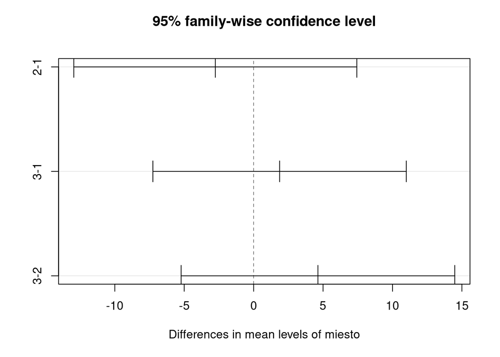

```r
plot(tpt)
```